# Lab2_Bologna

Justin Bologna

April 18, 2020

## Lab 2 - Descriptive Statistics and Basic Mapping

Today we are going to be examining a dataset of selected socioeconomic indicators in Chicago form the period 2008 - 2012. The file was downloaded as a non-spatial CSV from the Chicago Data Portal website.

First, let’s set up our R environment and load the packages we need.

```r
setwd("~/UChicago 19-20/Spring/GIS III/wd/lab2")
library(sf)
library(dplyr)
library(spData)
```

Since our dataset of interest is non-spatial, we must joing it to a spatial shapefile of Chicago community areas. Let’s read these files into our R environment and join them.

```r
indicators <- read.csv("selected_indicators.csv", stringsAsFactors = FALSE)
ca <- st_read("ca.shp")
indicators[76,2] <- "OHARE"
indicators[,2] <- toupper(indicators[,2])
indicators <- rename(indicators, community = COMMUNITY.AREA.NAME)

indicators_spatial <- left_join(ca, indicators, by="community")
```

We had to tweak the names of some columns and fields to get them to match before we could join, but now we have a spatial version of the data. Let’s examine the summary statistics for a few select variables.

```r
summary(indicators_spatial[,c(14,16,17)])
```

```
##  PERCENT.AGED.25..WITHOUT.HIGH.SCHOOL.DIPLOMA PER.CAPITA.INCOME HARDSHIP.INDEX
##  Min.   : 2.50                                Min.   : 8201     Min.   : 1.00
##  1st Qu.:11.65                                1st Qu.:15641     1st Qu.:24.50
##  Median :18.50                                Median :21323     Median :51.00
##  Mean   :20.39                                Mean   :25688     Mean   :49.52
##  3rd Qu.:27.05                                3rd Qu.:30398     3rd Qu.:74.50
##  Max.   :54.80                                Max.   :88669     Max.   :98.00
##  NA's   :2                                    NA's   :2         NA's   :2
##           geometry
##  MULTIPOLYGON :77
##  epsg:4326    : 0
##  +proj=long...: 0
##
##
##
##
```

Next, let’s focus on one specific indicator: the hardship index. We can generate a histogram with the following code:

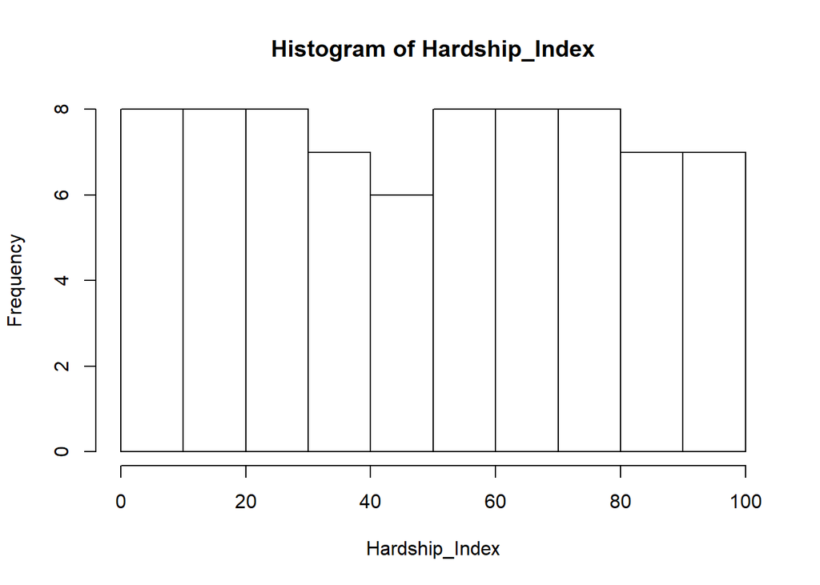

```r
Hardship_Index <- indicators_spatial$HARDSHIP.INDEX
hist(Hardship_Index)
```

Since we went through the trouble of making our dataset spatial, let’s map the Hardship Index too.

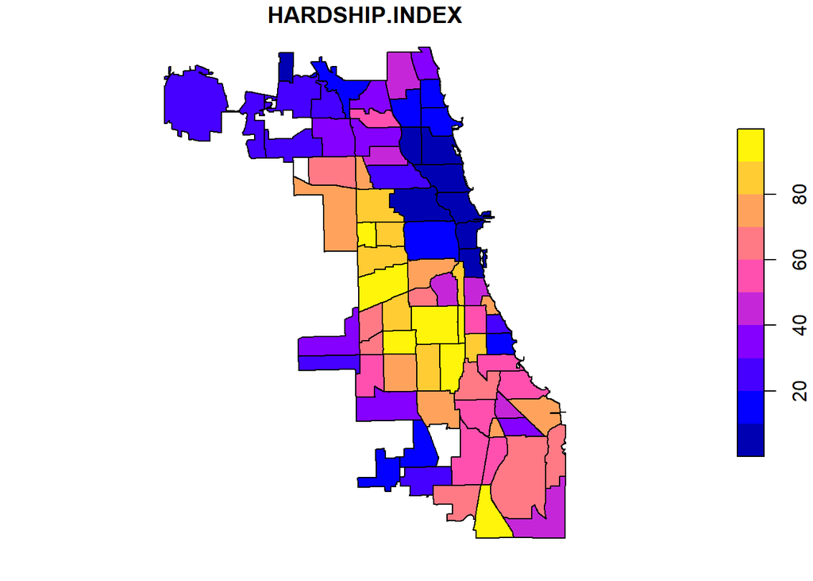

```r
plot(indicators_spatial[,17])
```

## Works Cited

Chicago Data Portal. (2014). *Census Data - Selected socioeconomic indicators in Chicago, 2008 - 2012* [CSV]. https://data.cityofchicago.org/Health-Human-Services/Census-Data-Selected-socioeconomic-indicators-in-C/kn9c-c2s2.

Chicago Data Portal. (2018). *Boundaries - Community Areas (current)* [Shapefile]. https://data.cityofchicago.org/Facilities-Geographic-Boundaries/Boundaries-Community-Areas-current-/cauq-8yn6.